# Predicting Alpha: Exploratory Analysis

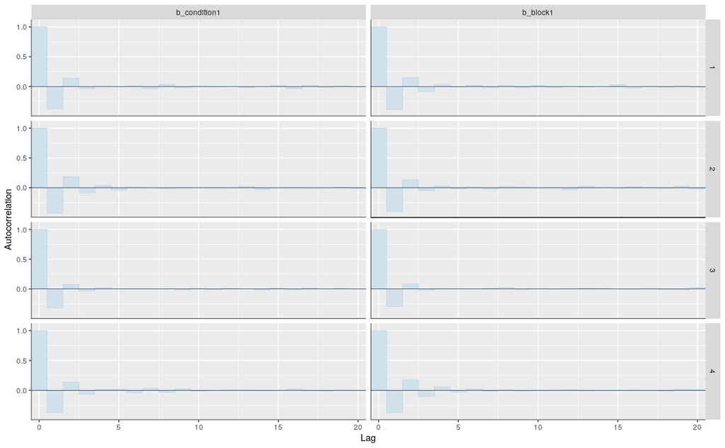

```r
mcmc_plot(m1_all, pars = c("condition", "block"), type = "acf_bar")
```

Model summary:

```r
summary(m1_all)
```

```
 Family: bernoulli
  Links: mu = logit
Formula: correct ~ condition + block + (1 | subject) + (1 | fact_id)
   Data: test (Number of observations: 4080)
Samples: 4 chains, each with iter = 10000; warmup = 5000; thin = 1;
         total post-warmup samples = 20000

Group-Level Effects:
~fact_id (Number of levels: 60)
              Estimate Est.Error l-95% CI u-95% CI Rhat Bulk_ESS Tail_ESS
sd(Intercept)     0.20      0.06     0.08     0.31 1.00     5985     4978

~subject (Number of levels: 68)
              Estimate Est.Error l-95% CI u-95% CI Rhat Bulk_ESS Tail_ESS
sd(Intercept)     0.54      0.06     0.43     0.67 1.00     7615    11912

Population-Level Effects:
           Estimate Est.Error l-95% CI u-95% CI Rhat Bulk_ESS Tail_ESS
Intercept     -0.29      0.08    -0.44    -0.14 1.00     8188    12283
condition1     0.03      0.07    -0.09     0.16 1.00    45067    14275
block1         0.40      0.07     0.27     0.53 1.00    43869    13753

Samples were drawn using sampling(NUTS). For each parameter, Bulk_ESS
and Tail_ESS are effective sample size measures, and Rhat is the potential
scale reduction factor on split chains (at convergence, Rhat = 1).
```

Visualise the model’s population-level estimates, along with their 95% credible intervals:

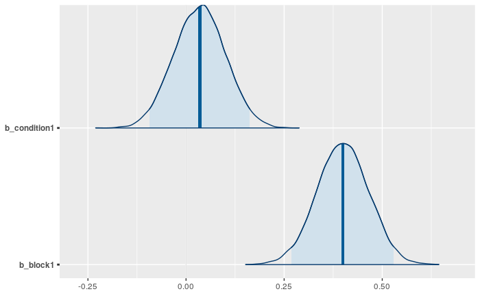

```r
mcmc_plot(m1_all, pars = c("condition", "block"), type = "areas", prob = .95)
```

Clearly, the evidence for an effect of condition basically disappears when the unstudied items are included in the model. The estimated distribution for the condition coefficient overlaps with zero.

```r
prior_density_at_zero <- dcauchy(0, 0, 1)
m1_all_posterior_samples <- posterior_samples(m1_all, pars = "b_condition1")$b_condition1
m1_all_posterior_density_at_zero <- density_ratio(m1_all_posterior_samples, point = 0)


xval <- seq(-2, 2, by = 0.01)
plot_prior <- dcauchy(xval, location = 0, scale = 1)
m1_all_plot_posterior <- density_ratio(x = m1_all_posterior_samples, y = NULL, point = xval) # Returns the density of the posterior at each point in x
m1_all_density <- tibble(xval = xval, Prior = plot_prior, Posterior = m1_all_plot_posterior)
```

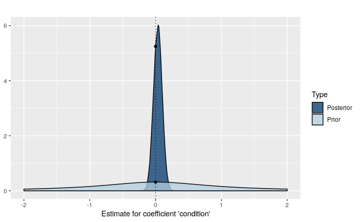

```r
gather(m1_all_density, -xval, key = "Type", value = "density") %>%
  mutate(density = ifelse(density < 0, 0, density)) %>%
  ggplot(aes(x = xval, y = density, fill = Type)) +
  geom_area(position = "identity", colour = "black", alpha = 0.75) +
  geom_vline(xintercept = 0, lty = 3) +
  annotate("point", x = c(0, 0), y = c(prior_density_at_zero, m1_all_posterior_density_at_zero)) +
  labs(x = "Estimate for coefficient 'condition'", y = NULL, title = "") +
  scale_fill_manual(values = c("#03396c", "#b3cde0"))
```

The evidence in favour of a non-zero coefficient for condition is evaluated by means of the Savage-Dickey density ratio: the ratio between the prior and posterior density at $\beta_{condition} = 0$ (the two points on the dotted line in the plot above).

```r
BF_condition_all <- prior_density_at_zero / m1_all_posterior_density_at_zero

BF_condition_all
```

```
[1] 0.06067671
```

The evidence in favour of an effect of condition is $BF_{10}$ = 0.06067671. Put differently, the evidence *against* an effect of condition is $BF_{01}$ = 16.48079.

(This means that a stopping rule based on this test, rather than the test on unstudied items only, would also have been satisfied, albeit with the evidence in favour of the null.)

## Add studied/not studied predictor

If we include items that were not studied during the learning session, the model we used is really no longer a reasonable model, since it does not account for probably the largest source of variance: whether or not the test item was studied beforehand.

The following model does include this predictor, as well as an interaction with condition.

```r
m1_all2 <- brm(
  correct ~ studied * condition + block + (1 | subject) + (1 | fact_id),
  family = bernoulli,
  data = test,
  prior = prior_m1,
  chains = 4,
  iter = 10000,
  save_all_pars = TRUE,
  sample_prior = TRUE,
  future = TRUE,
  seed = 0,
  file = "model_fits/m1_all2"
)
```

Compared to the model without the `studied` predictor, this model is immeasurably better:

```r
bayes_factor(m1_all2, m1_all)
```

```
Iteration: 1
Iteration: 2
Iteration: 3
Iteration: 4
Iteration: 5
Iteration: 6
Iteration: 7
Iteration: 1
Iteration: 2
Iteration: 3
Iteration: 4
Iteration: 5
Iteration: 6
Estimated Bayes factor in favor of m1_all2 over m1_all:    Inf
```

Also compare to simpler versions of the model with a `studied` predictor:

```r
m1_all3 <- brm(
  correct ~ studied : condition + condition + block + (1 | subject) + (1 | fact_id),
  family = bernoulli,
  data = test,
  prior = prior_m1,
  chains = 4,
  iter = 10000,
  save_all_pars = TRUE,
  sample_prior = TRUE,
  future = TRUE,
  seed = 0,
  file = "model_fits/m1_all3"
)


bayes_factor(m1_all3, m1_all2)
```

```
Iteration: 1
Iteration: 2
Iteration: 3
Iteration: 4
Iteration: 5
Iteration: 6
Iteration: 1
Iteration: 2
Iteration: 3
Iteration: 4
Iteration: 5
Iteration: 6
Estimated Bayes factor in favor of m1_all3 over m1_all2: 0.02668
```

Worse.

```r
m1_all4 <- brm(
  correct ~ studied + studied : condition  + block + (1 | subject) + (1 | fact_id),
  family = bernoulli,
  data = test,
  prior = prior_m1,
  chains = 4,
  iter = 10000,
  save_all_pars = TRUE,
  sample_prior = TRUE,
  future = TRUE,
  seed = 0,
  file = "model_fits/m1_all4"
)

bayes_factor(m1_all4, m1_all2)
```

```
Iteration: 1
Iteration: 2
Iteration: 3
Iteration: 4
Iteration: 5
Iteration: 6
Iteration: 1
Iteration: 2
Iteration: 3
Iteration: 4
Iteration: 5
Estimated Bayes factor in favor of m1_all4 over m1_all2: 1.26878
```

Slightly better.

```r
m1_all5 <- brm(
  correct ~ studied : condition  + block + (1 | subject) + (1 | fact_id),
  family = bernoulli,
  data = test,
  prior = prior_m1,
  chains = 4,
  iter = 10000,
  save_all_pars = TRUE,
  sample_prior = TRUE,
  future = TRUE,
  seed = 0,
  file = "model_fits/m1_all5"
)

bayes_factor(m1_all5, m1_all4)
```

```
Iteration: 1
Iteration: 2
Iteration: 3
Iteration: 4
Iteration: 5
Iteration: 6
Iteration: 7
Iteration: 1
Iteration: 2
Iteration: 3
Iteration: 4
Iteration: 5
Iteration: 6
Estimated Bayes factor in favor of m1_all5 over m1_all4: 0.03307
```

Worse.

So far, the best model is `m1_all4`.

```
No divergences to plot.
```

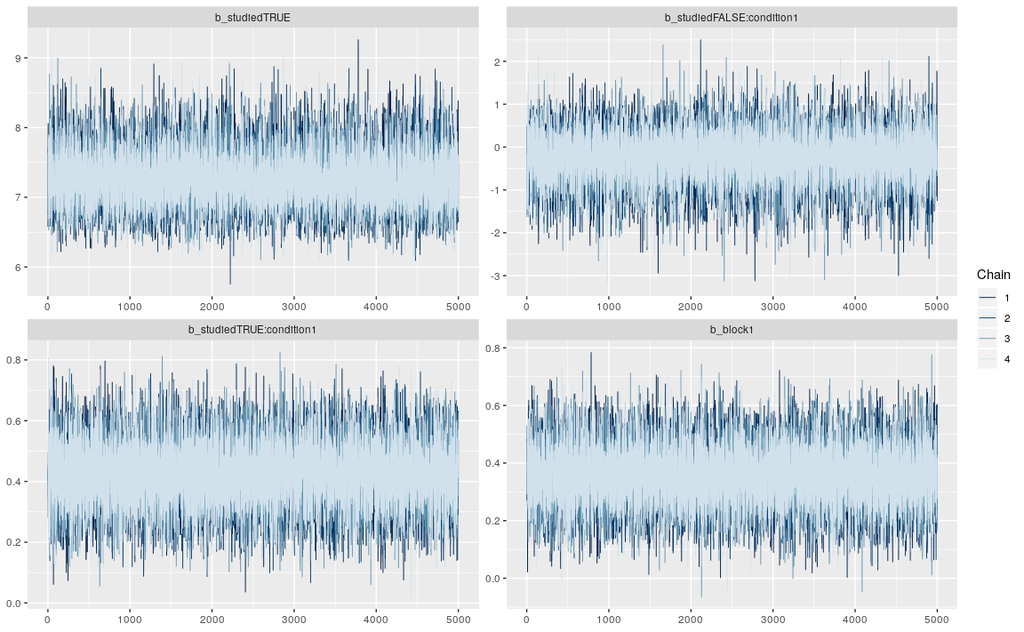

```r
mcmc_plot(m1_all4, pars = c("studied", "condition", "block"), type = "trace")
```

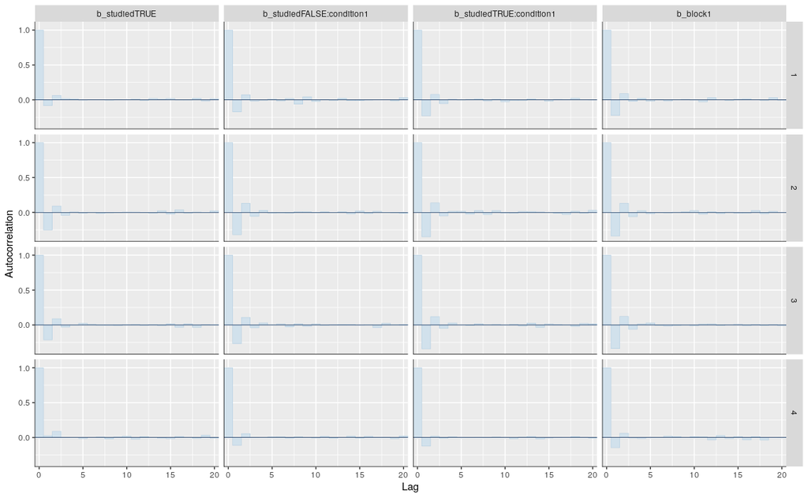

```r
mcmc_plot(m1_all4, pars = c("studied", "condition", "block"), type = "acf_bar")
```

Model summary:

```r
summary(m1_all4)
```

```
 Family: bernoulli
  Links: mu = logit
Formula: correct ~ studied + studied:condition + block + (1 | subject) + (1 | fact_id)
   Data: test (Number of observations: 4080)
Samples: 4 chains, each with iter = 10000; warmup = 5000; thin = 1;
         total post-warmup samples = 20000

Group-Level Effects:
~fact_id (Number of levels: 60)
              Estimate Est.Error l-95% CI u-95% CI Rhat Bulk_ESS Tail_ESS
sd(Intercept)     0.52      0.09     0.36     0.72 1.00     7036    11161

~subject (Number of levels: 68)
              Estimate Est.Error l-95% CI u-95% CI Rhat Bulk_ESS Tail_ESS
sd(Intercept)     0.65      0.09     0.49     0.85 1.00     6511    11938

Population-Level Effects:
                        Estimate Est.Error l-95% CI u-95% CI Rhat Bulk_ESS Tail_ESS
Intercept                  -5.92      0.41    -6.80    -5.17 1.00    21604    13336
studiedTRUE                 7.29      0.41     6.55     8.17 1.00    23973    12909
block1                      0.36      0.11     0.15     0.57 1.00    32202    14875
studiedFALSE:condition1    -0.25      0.62    -1.54     0.93 1.00    28595    12533
studiedTRUE:condition1      0.43      0.11     0.22     0.64 1.00    32265    14600

Samples were drawn using sampling(NUTS). For each parameter, Bulk_ESS
and Tail_ESS are effective sample size measures, and Rhat is the potential
scale reduction factor on split chains (at convergence, Rhat = 1).
```

Visualise the model’s population-level estimates (on logit scale), along with their 95% credible intervals:

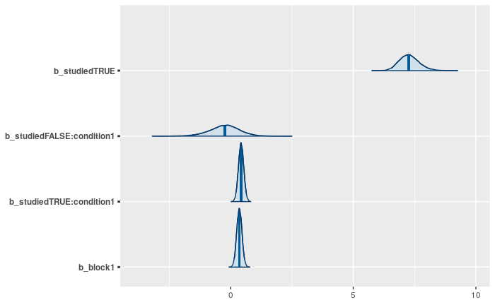

```r
mcmc_plot(m1_all4, pars = c("studied", "condition", "block"), type = "areas", prob = .95)
```

Interpretation:

- Test accuracy increases strongly if an item was studied during the preceding learning session.
- Given that an item was studied, test accuracy is higher if the item was studied in the Fact condition than if it was studied in the Default condition.
- Test accuracy is higher in the second block.

```r
prior_density_at_zero <- dcauchy(0, 0, 1)
m1_all4_posterior_samples <- posterior_samples(m1_all4, pars = "b_studiedTRUE:condition1")$`b_studiedTRUE:condition1`
m1_all4_posterior_density_at_zero <- density_ratio(m1_all4_posterior_samples, point = 0)


xval <- seq(-2, 2, by = 0.01)
plot_prior <- dcauchy(xval, location = 0, scale = 1)
m1_all4_plot_posterior <- density_ratio(x = m1_all4_posterior_samples, y = NULL, point = xval) # Returns the density of the posterior at each point in x
m1_all4_density <- tibble(xval = xval, Prior = plot_prior, Posterior = m1_all4_plot_posterior)
```

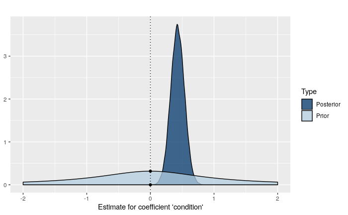

```r
gather(m1_all4_density, -xval, key = "Type", value = "density") %>%
  mutate(density = ifelse(density < 0, 0, density)) %>%
  ggplot(aes(x = xval, y = density, fill = Type)) +
  geom_area(position = "identity", colour = "black", alpha = 0.75) +
  geom_vline(xintercept = 0, lty = 3) +
  annotate("point", x = c(0, 0), y = c(prior_density_at_zero, m1_all4_posterior_density_at_zero)) +
  labs(x = "Estimate for coefficient 'condition'", y = NULL, title = "") +
  scale_fill_manual(values = c("#03396c", "#b3cde0"))
```

The evidence in favour of a non-zero coefficient for condition is evaluated by means of the Savage-Dickey density ratio: the ratio between the prior and posterior density at $\beta_{condition} = 0$ (the two points on the dotted line in the plot above).

```r
BF_condition_all4 <- prior_density_at_zero / m1_all4_posterior_density_at_zero

BF_condition_all4
```

```
[1] 618.9869
```

The evidence in favour of an effect of condition is $BF_{10}$ = 618.9869.

Using this model, we can predict participants’ test scores. Comparing them to the observed test scores confirms that the model is quite good at capturing the data.

```r
test_pred <- bind_cols(test, as.data.frame(fitted(m1_all4)))
```

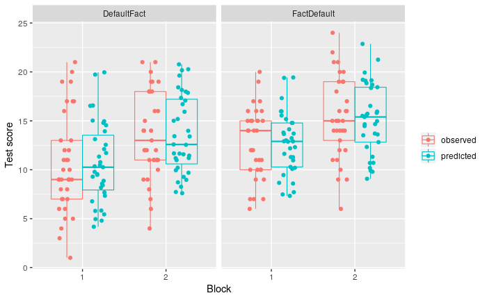

```r
test_scores_pred <- test_pred %>%
  group_by(subject, block, condition) %>%
  summarise(score = sum(correct),
            score_pred = sum(Estimate)) %>%
  mutate(condition_order = case_when(
    block == 1 && condition == "default" ~ "DefaultFact",
    block == 2 && condition == "fact" ~ "DefaultFact",
    block == 1 && condition == "fact" ~ "FactDefault",
    block == 2 && condition == "default" ~ "FactDefault"
  )) %>%
  ungroup() %>%
  mutate(condition_order = as.factor(condition_order)) %>%
  gather("type", "value", score, score_pred) %>%
  mutate(type = ifelse(type == "score", "observed", "predicted"))


ggplot(test_scores_pred, aes(x = block, y = value, colour = type)) +
  facet_grid(~ condition_order) +
  geom_boxplot(position = position_dodge(), fill = NA, size = 0.4) +
  geom_point(position = position_jitterdodge(0.2)) +
  labs(x = "Block", y = "Test score", colour = NULL)
```

# What if you only learn one block?

```r
test_studied_block1 <- filter(test_studied, block == 1)

m1_block1 <- brm(
  correct ~ condition + (1 | subject) + (1 | fact_id),
  family = bernoulli,
  data = test_studied_block1,
  prior = prior_m1,
  chains = 4,
  iter = 10000,
  save_all_pars = TRUE,
  sample_prior = TRUE,
  future = TRUE,
  seed = 0,
  file = "model_fits/m1_block1"
)
```

The effect of condition is even stronger if we only look at block 1:

```r
summary(m1_block1)
```

```
 Family: bernoulli
  Links: mu = logit
Formula: correct ~ condition + (1 | subject) + (1 | fact_id)
   Data: test_studied_block1 (Number of observations: 1057)
Samples: 4 chains, each with iter = 10000; warmup = 5000; thin = 1;
         total post-warmup samples = 20000

Group-Level Effects:
~fact_id (Number of levels: 60)
              Estimate Est.Error l-95% CI u-95% CI Rhat Bulk_ESS Tail_ESS
sd(Intercept)     0.38      0.15     0.07     0.66 1.00     3252     2387

~subject (Number of levels: 68)
              Estimate Est.Error l-95% CI u-95% CI Rhat Bulk_ESS Tail_ESS
sd(Intercept)     0.68      0.13     0.44     0.94 1.00     7924    10361

Population-Level Effects:
           Estimate Est.Error l-95% CI u-95% CI Rhat Bulk_ESS Tail_ESS
Intercept      1.16      0.13     0.91     1.43 1.00    11200    12521
condition1     0.63      0.22     0.20     1.08 1.00    12571    15017

Samples were drawn using sampling(NUTS). For each parameter, Bulk_ESS
and Tail_ESS are effective sample size measures, and Rhat is the potential
scale reduction factor on split chains (at convergence, Rhat = 1).
```

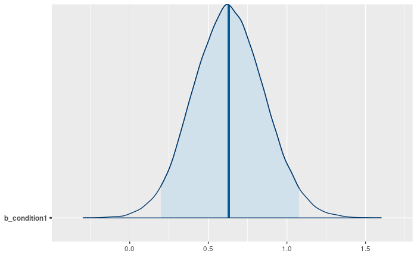

```r
mcmc_plot(m1_block1, pars = c("condition"), type = "areas", prob = .95)
```